# NYPD Shooting Report

2025-04-27

# 1. Import Libraries

```r
library(tidyverse)
library(lubridate)
```

# 2. Read Data In

```r
df <- read_csv("https://data.cityofnewyork.us/api/views/833y-fsy8/rows.csv?accessType=DOWNLOAD")
head(df)
```

```
## # A tibble: 6 × 21
##   INCIDENT_KEY OCCUR_DATE OCCUR_TIME BORO     LOC_OF_OCCUR_DESC PRECINCT
##          <dbl> <chr>      <time>     <chr>    <chr>                <dbl>
## 1    231974218 08/09/2021 01:06      BRONX    <NA>                    40
## 2    177934247 04/07/2018 19:48      BROOKLYN <NA>                    79
## 3    255028563 12/02/2022 22:57      BRONX    OUTSIDE                 47
## 4     25384540 11/19/2006 01:50      BROOKLYN <NA>                    66
## 5     72616285 05/09/2010 01:58      BRONX    <NA>                    46
## 6     85875439 07/22/2012 21:35      BRONX    <NA>                    42
## # ℹ 15 more variables: JURISDICTION_CODE <dbl>, LOC_CLASSFCTN_DESC <chr>,
## #   LOCATION_DESC <chr>, STATISTICAL_MURDER_FLAG <lgl>, PERP_AGE_GROUP <chr>,
## #   PERP_SEX <chr>, PERP_RACE <chr>, VIC_AGE_GROUP <chr>, VIC_SEX <chr>,
## #   VIC_RACE <chr>, X_COORD_CD <dbl>, Y_COORD_CD <dbl>, Latitude <dbl>,
## #   Longitude <dbl>, Lon_Lat <chr>
```

The data was imported directly from the NYC Open Data portal.  
This dataset contains detailed information regarding reported shooting incidents handled by the NYPD across all five boroughs of New York City, including location, demographics of involved parties, and the outcome of the incidents.  
(Source: [NYPD Shooting Incident Data (Historic)](https://data.cityofnewyork.us/Public-Safety/NYPD-Shooting-Incident-Data-Historic-/833y-fsy8/about_data))

# 3. Tidy Data

Looking at the columns from the previous head(df), we are able to determine columns we will not be utilizing for this assignment. These columns are PRECINCT , JURISDICTION_CODE, LOCATION_DESC , X_COORD_CD , Y_COORD_CD , LOC_OF_OCCUR_DESC , LOCATION_CLASSFCTN_DESC , Latitude, Longitude and Lon_Lat.

```r
df_2 <- df %>%
  select(
    INCIDENT_KEY,
    OCCUR_DATE,
    OCCUR_TIME,
    BORO,
    STATISTICAL_MURDER_FLAG,
    PERP_AGE_GROUP,
    PERP_SEX,
    PERP_RACE,
    VIC_AGE_GROUP,
    VIC_SEX,
    VIC_RACE
  )

# Fill NAs
df_2 <- df_2 %>%
  replace_na(list(PERP_AGE_GROUP = "Unknown", PERP_SEX = "Unknown", PERP_RACE = "Unknown"))

# Standardize cases
df_2$PERP_RACE <- str_to_title(df_2$PERP_RACE)
df_2$VIC_RACE <- str_to_title(df_2$VIC_RACE)
df_2$PERP_AGE_GROUP <- str_to_title(df_2$PERP_AGE_GROUP)
df_2$VIC_AGE_GROUP <- str_to_title(df_2$VIC_AGE_GROUP)

# Filter only valid entries
valid_age_groups <- c("<18", "18-24", "25-44", "45-64", "65+", "Unknown")
valid_race_groups <- c(
  "American Indian/Alaskan Native", "Asian / Pacific Islander",
  "Black", "Black Hispanic", "White", "White Hispanic", "Unknown"
)

df_2 <- df_2 %>%
  filter(PERP_AGE_GROUP %in% valid_age_groups,
         VIC_AGE_GROUP %in% valid_age_groups,
         PERP_RACE %in% valid_race_groups,
         VIC_RACE %in% valid_race_groups)

# Factors
df_2$BORO <- as.factor(df_2$BORO)
df_2$PERP_AGE_GROUP <- as.factor(df_2$PERP_AGE_GROUP)
df_2$PERP_SEX <- as.factor(df_2$PERP_SEX)
df_2$PERP_RACE <- as.factor(df_2$PERP_RACE)
df_2$VIC_AGE_GROUP <- as.factor(df_2$VIC_AGE_GROUP)
df_2$VIC_SEX <- as.factor(df_2$VIC_SEX)
df_2$VIC_RACE <- as.factor(df_2$VIC_RACE)

summary(df_2)
```

```
##   INCIDENT_KEY        OCCUR_DATE          OCCUR_TIME
##  Min.   :  9953245   Length:28110       Min.   :00:00:00.000000
##  1st Qu.: 64773375   Class :character   1st Qu.:03:30:00.000000
##  Median : 92077622   Mode  :character   Median :15:15:00.000000
##  Mean   :126084776                      Mean   :12:44:33.942369
##  3rd Qu.:198936522                      3rd Qu.:20:41:00.000000
##  Max.   :298699604                      Max.   :23:59:00.000000
##
##             BORO       STATISTICAL_MURDER_FLAG PERP_AGE_GROUP     PERP_SEX
##  BRONX        : 8314   Mode :logical           <18    : 1805   F      :  461
##  BROOKLYN     :11048   FALSE:22576             18-24  : 6629   M      :16839
##  MANHATTAN    : 3785   TRUE :5534              25-44  : 6342   U      : 1500
##  QUEENS       : 4169                           45-64  :  775   Unknown: 9310
##  STATEN ISLAND:  794                           65+    :   67
##                                                Unknown:12492
##
##                           PERP_RACE     VIC_AGE_GROUP   VIC_SEX
##  American Indian/Alaskan Native:    2   <18    : 2925   F: 2715
##  Asian / Pacific Islander      :  184   18-24  :10218   M:25383
##  Black                         :12319   25-44  :12701   U:   12
##  Black Hispanic                : 1487   45-64  : 1983
##  Unknown                       :11148   65+    :  215
##  White                         :  305   Unknown:   68
##  White Hispanic                : 2665
##                            VIC_RACE
##  American Indian/Alaskan Native:   11
##  Asian / Pacific Islander      :  440
##  Black                         :19848
##  Black Hispanic                : 2770
##  Unknown                       :   71
##  White                         :  720
##  White Hispanic                : 4250
```

Looking over the returned values, we are able to tell that there is missing data from a handful of columns. We can understand a sense of ambiguity in the race, sex and age of the perpetrator that could be present in possibly ongoing and active investigations. To address these gaps of information, we will be calling these occurrences “Unknown” as to avoid potentially mishandling meaningful data.

# 4. Incidents and Murder by Borough

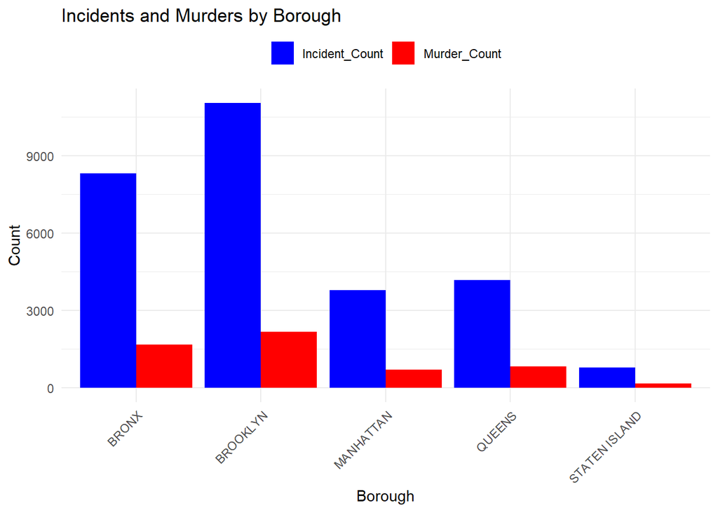

```r
df_2 %>%
  group_by(BORO) %>%
  summarize(
    Incident_Count = n(),
    Murder_Count = sum(STATISTICAL_MURDER_FLAG)
  ) %>%
  pivot_longer(cols = c(Incident_Count, Murder_Count), names_to = "Type", values_to = "Count") %>%
  ggplot(aes(x = BORO, y = Count, fill = Type)) +
  geom_bar(stat = "identity", position = "dodge") +
  labs(title = "Incidents and Murders by Borough", y = "Count", x = "Borough") +
  scale_fill_manual(values = c("Incident_Count" = "blue", "Murder_Count" = "red")) +
  theme_minimal() +
  theme(
    axis.text.x = element_text(angle = 45, hjust = 1),
    legend.position = "top",
    legend.title = element_blank()
  )
```

We are able to see that among the New York boroughs, Brooklyn by far has the most incident count as well  
as having the highest murder count with Staten Island coming in last with the fewest incident count and murder count.  
This led to another question of, who are the people making up these incidents and murders?

# 5. Heatmaps by Perpetrator and Victim Race

```r
density_data <- df_2 %>%
  group_by(BORO, PERP_RACE) %>%
  summarize(density = n()) %>%
  ungroup()
```

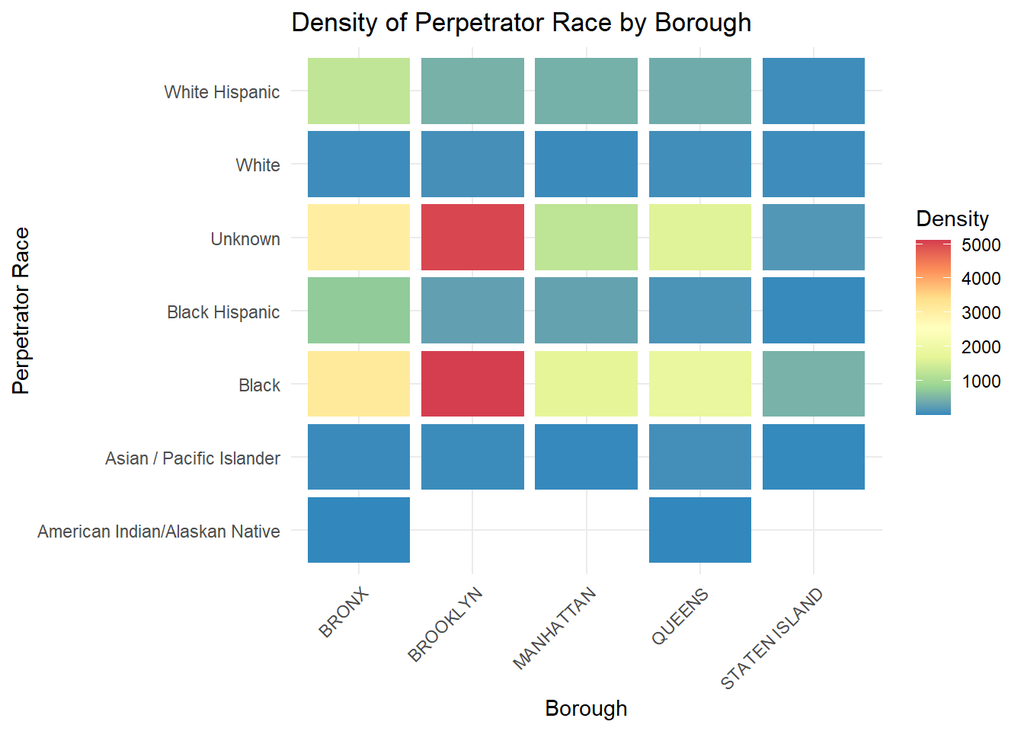

```r
ggplot(density_data, aes(x = BORO, y = PERP_RACE, fill = density)) +
  geom_tile(width = 0.9, height = 0.9) +
  labs(title = "Density of Perpetrator Race by Borough", x = "Borough", y = "Perpetrator Race", fill = "Density") +
  scale_fill_distiller(palette = "Spectral", direction = -1, breaks = waiver()) +
  theme_minimal() +
  theme(axis.text.x = element_text(angle = 45, hjust = 1))
```

```r
density_data <- df_2 %>%
  group_by(BORO, VIC_RACE) %>%
  summarize(density = n()) %>%
  ungroup()
```

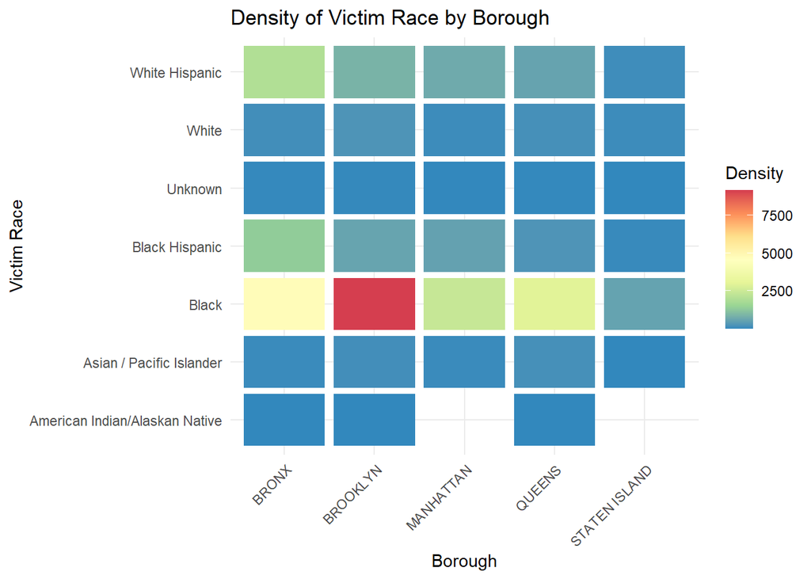

```r
ggplot(density_data, aes(x = BORO, y = VIC_RACE, fill = density)) +
  geom_tile(width = 0.9, height = 0.9) +
  labs(title = "Density of Victim Race by Borough", x = "Borough", y = "Victim Race", fill = "Density") +
  scale_fill_distiller(palette = "Spectral", direction = -1, breaks = waiver()) +
  theme_minimal() +
  theme(axis.text.x = element_text(angle = 45, hjust = 1))
```

The heatmaps show the racial distribution of perpetrators and victims across boroughs.  
Noticeable densities are concentrated in Black and Hispanic groups, consistent with previous research on demographic representation in crime data.

# 6. Heatmaps by Perpetrator and Victim Age

```r
density_data <- df_2 %>%
  group_by(BORO, PERP_AGE_GROUP) %>%
  summarize(density = n()) %>%
  ungroup()
```

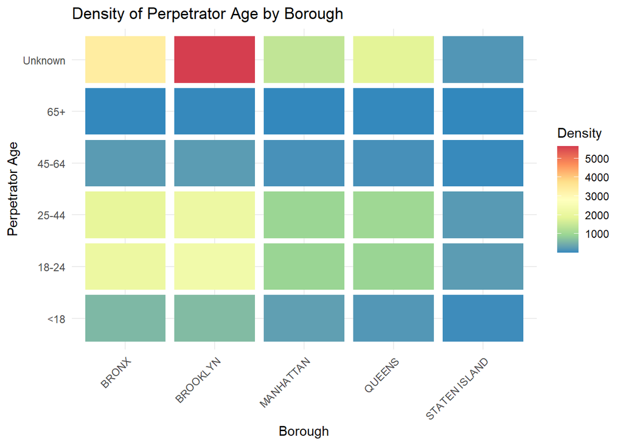

```r
ggplot(density_data, aes(x = BORO, y = PERP_AGE_GROUP, fill = density)) +
  geom_tile(width = 0.9, height = 0.9) +
  labs(title = "Density of Perpetrator Age by Borough", x = "Borough", y = "Perpetrator Age", fill = "Density") +
  scale_fill_distiller(palette = "Spectral", direction = -1, breaks = waiver()) +
  theme_minimal() +
  theme(axis.text.x = element_text(angle = 45, hjust = 1))
```

```r
density_data <- df_2 %>%
  group_by(BORO, VIC_AGE_GROUP) %>%
  summarize(density = n()) %>%
  ungroup()
```

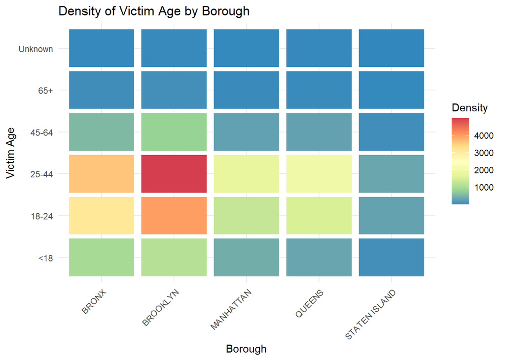

```r
ggplot(density_data, aes(x = BORO, y = VIC_AGE_GROUP, fill = density)) +
  geom_tile(width = 0.9, height = 0.9) +
  labs(title = "Density of Victim Age by Borough", x = "Borough", y = "Victim Age", fill = "Density") +
  scale_fill_distiller(palette = "Spectral", direction = -1, breaks = waiver()) +
  theme_minimal() +
  theme(axis.text.x = element_text(angle = 45, hjust = 1))
```

# 7. Logistic Regression Model

```r
df_2$OCCUR_DAY <- mdy(df_2$OCCUR_DATE)
df_2$OCCUR_DAY <- wday(df_2$OCCUR_DAY, label = TRUE)
df_2$OCCUR_HOUR <- hour(hms(as.character(df_2$OCCUR_TIME)))

glm.fit <- glm(
  STATISTICAL_MURDER_FLAG ~ PERP_RACE + PERP_SEX + PERP_AGE_GROUP + OCCUR_HOUR + OCCUR_DAY + BORO,
  family = binomial,
  data = df_2
)

summary(glm.fit)
```

```
##
## Call:
## glm(formula = STATISTICAL_MURDER_FLAG ~ PERP_RACE + PERP_SEX +
##     PERP_AGE_GROUP + OCCUR_HOUR + OCCUR_DAY + BORO, family = binomial,
##     data = df_2)
##
## Coefficients:
##                                     Estimate Std. Error z value Pr(>|z|)
## (Intercept)                       -10.762511  84.449051  -0.127 0.898589
## PERP_RACEAsian / Pacific Islander   9.876379  84.449172   0.117 0.906899
## PERP_RACEBlack                      9.491575  84.449017   0.112 0.910511
## PERP_RACEBlack Hispanic             9.457385  84.449039   0.112 0.910832
## PERP_RACEUnknown                    8.878301  84.449294   0.105 0.916271
## PERP_RACEWhite                     10.052822  84.449102   0.119 0.905244
## PERP_RACEWhite Hispanic             9.619790  84.449025   0.114 0.909307
## PERP_SEXM                          -0.198700   0.107856  -1.842 0.065436 .
## PERP_SEXU                           1.639998   0.279510   5.867 4.43e-09 ***
## PERP_SEXUnknown                     2.819700   0.272462  10.349  < 2e-16 ***
## PERP_AGE_GROUP18-24                 0.164986   0.067974   2.427 0.015216 *
## PERP_AGE_GROUP25-44                 0.461225   0.067380   6.845 7.64e-12 ***
## PERP_AGE_GROUP45-64                 0.796829   0.097810   8.147 3.74e-16 ***
## PERP_AGE_GROUP65+                   0.881216   0.262964   3.351 0.000805 ***
## PERP_AGE_GROUPUnknown              -2.409838   0.176610 -13.645  < 2e-16 ***
## OCCUR_HOUR                         -0.002279   0.001887  -1.208 0.227189
## OCCUR_DAY.L                        -0.043244   0.037749  -1.146 0.251983
## OCCUR_DAY.Q                        -0.053544   0.040319  -1.328 0.184180
## OCCUR_DAY.C                        -0.059956   0.040725  -1.472 0.140964
## OCCUR_DAY^4                        -0.005167   0.041398  -0.125 0.900681
## OCCUR_DAY^5                         0.021086   0.043542   0.484 0.628203
## OCCUR_DAY^6                        -0.088034   0.044618  -1.973 0.048487 *
## BOROBROOKLYN                        0.031435   0.037908   0.829 0.406954
## BOROMANHATTAN                      -0.121878   0.050944  -2.392 0.016740 *
## BOROQUEENS                         -0.013725   0.048945  -0.280 0.779153
## BOROSTATEN ISLAND                  -0.108595   0.094301  -1.152 0.249493
## ---
## Signif. codes:  0 '***' 0.001 '**' 0.01 '*' 0.05 '.' 0.1 ' ' 1
##
## (Dispersion parameter for binomial family taken to be 1)
##
##     Null deviance: 27887  on 28109  degrees of freedom
## Residual deviance: 26764  on 28084  degrees of freedom
## AIC: 26816
##
## Number of Fisher Scoring iterations: 9
```

# 8. Identifying Bias

Dealing with data always carries the threat of one’s bias showing through in how data is handled and interpreted.  
Although I did not have any biases towards specific boroughs, I acknowledge that datasets from police departments must be treated carefully, considering historical over-policing concerns, particularly in Black and Hispanic communities.

In future analysis, layering in demographic data of borough populations could help clarify these relationships.  
Furthermore, it would be valuable to study how reporting practices or societal factors may influence the observed trends beyond raw numbers.

# 9. Resources

- [NYPD Shooting Incident Data (Historic)](https://catalog.data.gov/dataset/nypd-shooting-incident-data-historic)
- [A Closer Look at Stop-and-Frisk in NYC - NYCLU](https://www.nyclu.org/en/closer-look-stop-and-frisk-nyc)